# Results

```r
mean(data$time_until_event_clear)
```

```
[1] 9948.411
```

By taking a look at the scatterplot and the overall mean, it can be inferred that a few crimes that take more than 20,000 minutes to clear (almost 2 weeks) are skewing the data. Let’s take a look at this data and see what kind of crimes are associated with such long clearance times, and, where these crimes are located.

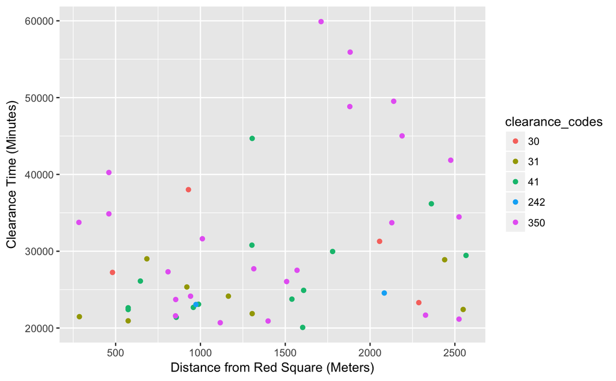

```r
# Resetting the data for the clearance times
data <- read.csv('../maps-api-test/2016-2017-Clean.csv', header = TRUE)
data <- filter(data, !str_detect(Event.Clearance.Description, "HARBOR - DEBRIS, NAVIGATIONAL HAZARDS"))
data <- filter(data, Event.Clearance.Description != 'CRISIS COMPLAINT - GENERAL') # filtering out data that is under the Crisis Complaint Description
data.over.twenty <- filter(data, time_until_event_clear > 20000) # filtering out data that takes 20000 minutes or under to clear
data <- data.over.twenty
clearance_codes <- factor(data$Event.Clearance.Code)
# plotting the scatter plot with distance from Red Square and clearance times
clearance.plot <- ggplot(data) +
       geom_point(aes(x = data$dist, y = data$time_until_event_clear, colour = clearance_codes), stat = 'identity') +
      xlab('Distance from Red Square (Meters)') +
      ylab('Clearance Time (Minutes)')
clearance.plot
```

By taking a look at the new scatter plot with the filtered data, we can see that crimes with clearance code 350 (crimes under the Event Clearance Group, “Hazards”) seem to be taking the longest time. We can confirm this by running a mode and see the mean clearance time for “Hazards”.

```r
hazards <- filter(data, Event.Clearance.Code == 350)
mean(hazards$time_until_event_clear) # Mean time is 33575.17 minutes, or about 23 days. We will filter these data points out because of the skew.
```

```
[1] 33575.17
```

[figure not shown]

```r
data <- filter(data, Event.Clearance.Code != 350) # filtering out hazards
ggmap(seattle) +
  geom_point(data = data, aes(x = Longitude, y = Latitude, colour = time_until_event_clear), alpha = 0.5) +
  scale_colour_gradient(low = "blue", high = "red")
```

Now that we have properly cleaned this data, we can begin to explore clustering.

[figure not shown]